# Berenice Castillo, MSW, MS

Berenice

2019-05-28

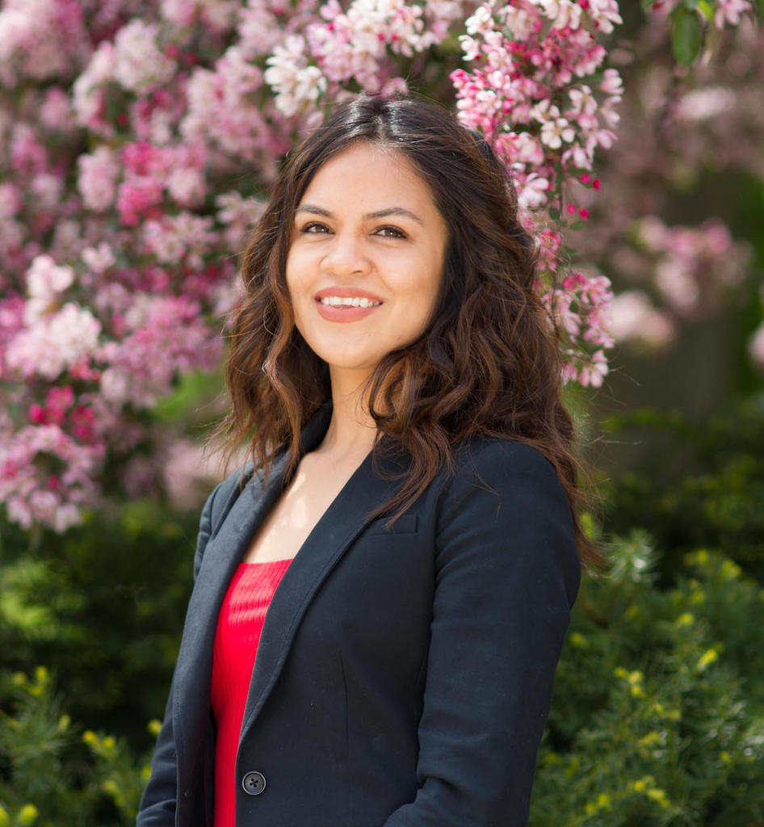

bcastil@umich.edu

$\color{red}{\text{Eduacation}}$

## PhD Social Work & Developmental Psychology – Expected 2021

## Master of Science (MS) Psychology –2019

## Master of Social Work (MSW) – 2015

#### University of Southern California

## Bachelor of Arts (BA) – 2013

#### University of California, Santa Cruz

$\color{red}{\text{Publications}}$

[Grogan-Kaylor, A., Burlaka, V., Ma, J., Lee, S., Castillo, B., & Churakova, I. (2018). Predictors of parental use of corporal punishment in Ukraine. Children and youth services review, 88, 66-73.](https://www.sciencedirect.com/science/article/pii/S0190740917310150)

[Castro, Y., Bares, C. B., Castillo, B., & Kennedy, A. (2018). Sociodemographics, but not Acculturation Proxies, Account for Differences in Lifetime Cessation between White and Hispanic Smokers. Ethnicity & disease, 28(3), 145-152.](https://europepmc.org/articles/pmc6051509)

$\color{red}{\text{Funding/Awards}}$

$\color{blue}{\text{University of Michigan}}$

2019 Institute for Social Research Jerald and Virginia Bachman Research Fellowship - $8,000

2019 Rackham Bobbe and Jon Bridge Award - $4,500

2019 Faculty Allies for Diversity Writing Fellowship - $2,000

2018 S.W. Kellogg Family Foundation Fellowship - $10,000

2018 School of Social Work Grant - $5,000

2018 Learning Community Manuscript Award - $4,000

2018 School of Social Work Summer Research Award - $8,000

2018 Society of Multivariate Experimental Psychology Award - $1,000

2018 Department of Psychology Training Grant - $1,000

2018 Faculty Allies for Diversity Writing Fellowship - $2,000

2018 School of Social Work Dean’s Travel Grant -$400

2018 Rackham Travel Grant - $800

2017 The University of Michigan President’s Advisory Committee on Labor Standards and Human Rights (PACLSHR) Grant - $5,000

2017 School of Social Work Deans Travel Grant - $400

2016-2017 Rackham Merit Fellowship - $10,500

2016 Underrepresented Student School of Social Work Award - $1,000

2016 Rackham Summer Training Grant - $1,500

2016 Rackham Travel Grant - $800

2016 School of Social Work Dean’s Travel Grant - $400

2015 School of Social Work Dean’s Travel Grant - $400

2015 Rackham Travel Grant - $800

2015-2016 Rackham Merit Fellowship - $10,500

$\color{blue}{\text{University of Southern California }}$

2015 #Gladys M. Salit Award - $3,000

$\color{blue}{\text{University of California, Santa Cruz}}$

2013 Herman Blake Award - $1,000

2013 Senior Thesis Research Award - $400